# Análise Exploratória de Dados

Introdução à Inferência Estatística- Parte 1

Autor

Data de Publicação

25 de junho de 2025

# 1 População e Amostra

## 1.1 Qualidade do Whisky: População e Amostra

```
# A tibble: 3 × 3
  Característica      `Valor Real` Significado
  <chr>               <chr>        <chr>
1 Tamanho (N)         46.000       Total de barris produzidos em 2024
2 Qualidade média (μ) 7.2          Qualidade média de toda a produção
3 Desvio padrão (σ)   0.91         Variabilidade da qualidade dos barris
```

```
# A tibble: 3 × 3
  Característica      `Valor Calculado` Interpretação
  <chr>                           <dbl> <chr>
1 Tamanho (n)                     50    amostra
2 Qualidade média (x̄)              7.22 estimativa de μ
3 Desvio- padrão (s)               1    estimativa do σ
```

## 1.2 Comparação: Parâmetros vs Estimativas

```
# A tibble: 3 × 4
  Medida          População  Amostra  `Qualidade da Estimativa`
  <chr>           <chr>      <chr>    <chr>
1 Tamanho         N = 46.000 n = 50   Amostra = 0,11% da população
2 Qualidade Média μ = 7.2    x̄ = 7.22 Boa estimativa
3 Desvio Padrão   σ = 0.91   s = 1    Boa estimativa
```

## 1.3 Verificação Visual da Representatividade

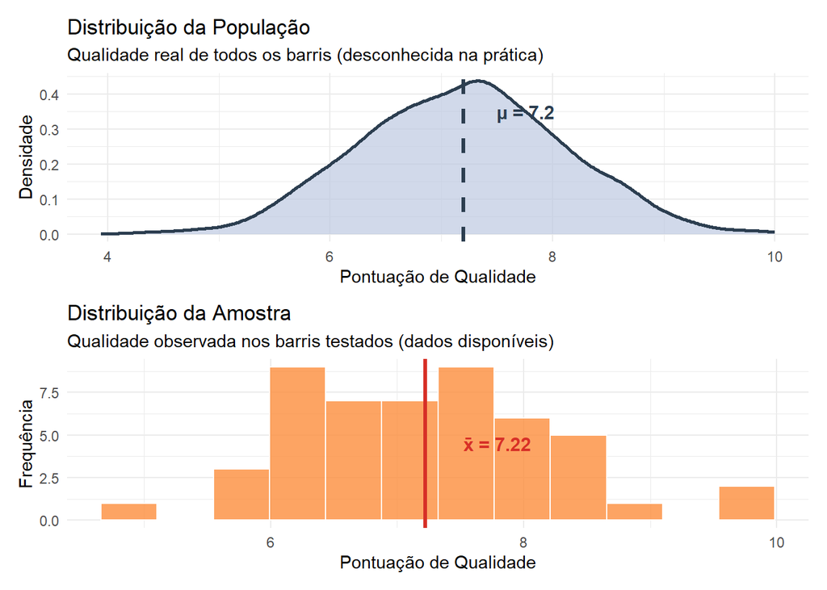

## 1.4 Exemplo: Satisfação de Clientes

Analista de e-commerce com 50.000 clientes ativos precisa estimar satisfação média para estratégias de retenção. Entrevistar todos seria proibitivo. Solução: amostra de 80 clientes para obter uma estimativa confiável.

```
# A tibble: 4 × 2
  Característica           `Valor Verdadeiro`
  <chr>                    <chr>
1 Total de clientes        50.000
2 Satisfação média (μ)     7.49
3 Desvio padrão (σ)        1.18
4 % muito satisfeitos (≥8) 33.8%
```

```
# A tibble: 4 × 3
  Resultado              Valor Interpretação
  <chr>                  <chr> <chr>
1 Clientes entrevistados 80    Tamanho da amostra
2 Satisfação média (x̄)   7.632 estimativa de μ
3 Desvio padrão (s)      1.229 estimativa do σ
4 % muito satisfeitos    40%   estimativa da % de clientes altamente satisfeitos
```

## 1.5 Quiz 1

**Cenário:** Empresa com 8.000 garrafas de vinho. Analista seleciona 120 garrafas para avaliação de qualidade por especialistas.

**Identifique:**

1. Qual é a população?
2. Qual é a amostra?
3. O que representa $\mu$?
4. O que representa $\bar{x}$?
5. Por que não avaliar todas as garrafas?

## 1.6 Quiz 2

**Cenário:** Rede com 1.200 farmácias. Analista seleciona 80 lojas para estudar ticket médio.

**Identifique:**

1. Qual é a população?
2. Qual é a amostra?
3. O que representa $\mu$?
4. O que representa $\bar{x}$?
5. Vantagens da abordagem amostral?

# 2 Amostragem

## 2.1 O que é Amostragem?

**Amostragem** é o processo de selecionar um subconjunto representativo de uma população.

**Características de uma Boa Amostra:**

- **Representativa**: Reflete características da população
- **Tamanho adequado**: Equilibra precisão e custo
- **Sem viés**: Processo não favorece grupos específicos
- **Aleatória**: Em amostragem probabilística, probabilidade conhecida de seleção

**Princípio fundamental**: Apenas amostras probabilísticas permitem inferência estatística válida.

## 2.2 Amostragem Aleatória Simples em R

Exemplo com Dados Municipais do PNUD (`pnud_muni`)

```r
# Carregar pacotes
library(abjData)   # Fornece dados municipais do PNUD

# Carregar a base completa
data("pnud_muni")

# Filtrar apenas os dados mais recentes
dados_recentes <- pnud_muni %>%
  filter(ano == max(ano))  # ano mais recente disponível

# Verificar estrutura
glimpse(dados_recentes)
```

```
Rows: 5,565
Columns: 124
$ uf                    <int> 11, 11, 11, 11, 11, 11, 11, 11, 11, 11, 11, 11, …
$ ano                   <int> 2010, 2010, 2010, 2010, 2010, 2010, 2010, 2010, …
$ codmun6               <int> 110001, 110002, 110003, 110004, 110005, 110006, …
$ codmun7               <int> 1100015, 1100023, 1100031, 1100049, 1100056, 110…
$ municipio             <chr> "ALTA FLORESTA D'OESTE", "ARIQUEMES", "CABIXI", …
$ espvida               <dbl> 70.75, 73.36, 70.39, 74.27, 72.94, 73.81, 71.45,…
$ fectot                <dbl> 2.24, 1.91, 2.15, 1.90, 2.12, 1.89, 2.29, 2.72, …
$ mort1                 <dbl> 23.80, 19.20, 24.80, 14.30, 18.10, 16.10, 21.90,…
$ mort5                 <dbl> 25.49, 20.53, 26.58, 15.38, 19.42, 17.28, 23.45,…
$ razdep                <dbl> 47.37, 46.68, 48.12, 43.79, 45.67, 45.82, 46.32,…
$ t_env                 <dbl> 5.84, 4.36, 6.87, 5.57, 6.44, 7.51, 5.67, 3.82, …
$ e_anosestudo          <dbl> 8.67, 9.18, 10.09, 9.74, 10.22, 10.40, 9.82, 9.2…
$ t_atraso_0_basico     <dbl> 57.62, 58.43, 66.22, 66.69, 72.15, 68.55, 67.01,…
```

[output cut: 111 more lines]

## 2.3 Amostragem Estratificada com o pacote `sampling`

Exemplo com Dados Municipais do PNUD (`pnud_muni`)

```r
# Carregar base de dados e filtrar o ano mais recente
data("pnud_muni")
dados_recentes <- pnud_muni %>%
  filter(ano == max(ano)) %>%
  select(uf, municipio, pop, espvida, rdpc, idhm)

# Tamanho total da amostra desejada
n_total <- 150

# Calcular tamanho proporcional da amostra por UF
tamanhos <- dados_recentes %>%
  # Contar o número de municípios em cada UF
  count(uf, name = "n_uf") %>%
  # Calcular a proporção de municípios da UF em relação ao total de municípios
  mutate(
    prop = n_uf / sum(n_uf),
    # Determinar o tamanho da amostra da UF proporcional ao total desejado
    n_amostra = round(prop * n_total),
    # Corrigir possíveis casos com zero observações (garante mínimo de 1)
    n_amostra = if_else(n_amostra == 0, 1L, n_amostra)
  )


# Realizar amostragem estratificada proporcional
set.seed(123)
amostra_ids <- sampling::strata(
  data = dados_recentes,           # data frame com a população (municípios do ano mais recente)
  stratanames = "uf",              # variável que define os estratos
  size = tamanhos$n_amostra,       # número de unidades a serem sorteadas por estrato (UF)
  method = "srswor"                # aas sem reposição
)

# Selecionar observações da amostra
amostra_proporcional <- dados_recentes[amostra_ids$ID_unit, ]
```

👉 A função `strata()` sorteia municípios **proporcionalmente à quantidade por UF**, garantindo pelo menos 1 município por estado.

👉 `ID_unit` contém os índices sorteados que usamos para extrair a amostra final.

## 2.4 Visualizando a Amostra Estratificada

Quantos Municípios Foram Sorteados por UF?

```r
# Contar número de municípios sorteados por UF
amostra_proporcional %>%
  count(uf, name = "n_sorteados") %>%
  arrange(desc(n_sorteados))
```

```
# A tibble: 27 × 2
      uf n_sorteados
   <int>       <int>
 1    31          23
 2    35          17
 3    43          13
 4    29          11
 5    41          11
 6    42           8
 7    52           7
 8    21           6
 9    22           6
10    25           6
# ℹ 17 more rows
```

## 2.5 Exercício

Aplicar os conceitos aprendidos de amostragem aos dados do PNUD:

1. Filtrar os dados para o ano mais recente disponível
2. Criar uma **amostra estratificada proporcional por UF** com 150 municípios
3. Estime a média do IDHM da amostra estratificada
- Dicas:
- Use a base `pnud_muni` do pacote `abjData`
- Utilize `set.seed(123)` para reprodutibilidade
- Para a amostragem estratificada, siga o padrão visto nos slides anteriores

# 3 Parâmetro, Estimador, Estatística e Estimativa

## 3.1 Quiz 3

Identifique: Parâmetro, Estimador, Estatística ou Estimativa?

Uma empresa de e-commerce analisa seus pedidos:

1. A fórmula $S^2 = \frac{\sum(X_i - \bar{X})^2}{n-1}$ para calcular variância
2. O valor R$ 127,50 calculado como média de 1.000 pedidos
3. A verdadeira proporção de clientes satisfeitos (nota ≥ 8)
4. A variável aleatória $\hat{p}$ = proporção amostral de satisfeitos
5. O desvio padrão σ = R$ 45,00 de todos os pedidos históricos

# 4 Distribuição Amostral

## 4.1 O Problema Central da Inferência Estatística

Um analista de dados coleta uma amostra de 100 funcionários e calcula satisfação média $\bar{x} = 7.2$. Mas se ele repetisse o processo com outra amostra de 100 funcionários, obteria $\bar{x} = 7.0$. Uma terceira amostra resultaria em $\bar{x} = 7.4$.

**A Distribuição Amostral** é a distribuição de probabilidade de todas as possíveis médias amostrais que poderíamos obter se repetíssemos o processo de amostragem infinitas vezes.

**Por que isso é importante?** A distribuição amostral nos permite quantificar a variabilidade dos estimadores e fundamenta todos os métodos de inferência estatística.

## 4.2 Simulação: Visualizando uma Distribuição Amostral

Simularemos 1.000 amostras diferentes para observar como as médias amostrais se distribuem. Isso permitirá visualizar concretamente o conceito de distribuição amostral.

**Cenário**: População de 50.000 funcionários com satisfação média $\mu = 7.5$ e desvio-padrão $\sigma = 1.2$. Cada amostra terá 50 funcionários.

```
# A tibble: 3 × 2
  Parâmetro                  Valor
  <chr>                      <dbl>
1 μ (média populacional)      7.50
2 σ (desvio populacional)     1.19
3 N (tamanho)             50000
```

```
# A tibble: 5 × 2
  Propriedade                      Valor
  <chr>                            <dbl>
1 Média das médias amostrais       7.50
2 Erro padrão empírico (observado) 0.17
3 Erro padrão teórico (fórmula)    0.168
4 Média populacional (μ)           7.50
5 Diferença (empírico - teórico)   0.002
```

## 4.3 Visualizando a Distribuição Amostral

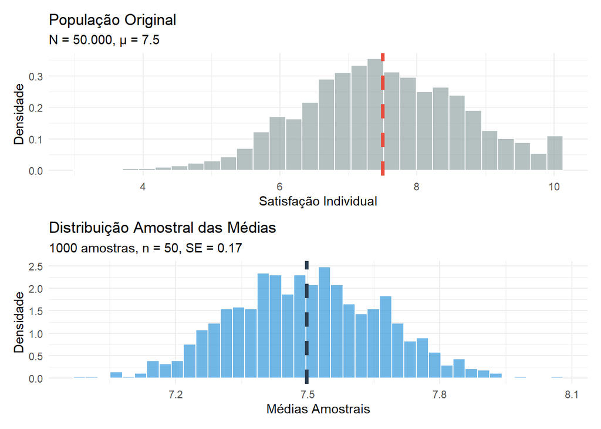

## 4.4 Simulação: Proporção de Clientes Satisfeitos

```
# A tibble: 3 × 2
  Característica                Valor
  <chr>                         <dbl>
1 Tamanho da população      20000
2 Proporção satisfeitos (p)     0.681
3 Número de satisfeitos     13627
```

```
# A tibble: 5 × 2
  Estatística                      Valor
  <chr>                            <dbl>
1 Proporção populacional (p)       0.681
2 Média das proporções amostrais   0.682
3 Erro padrão empírico (observado) 0.046
4 Erro padrão teórico (fórmula)    0.047
5 Diferença entre erros padrão     0
```

## 4.5 Visualizando a Distribuição Amostral da Proporção

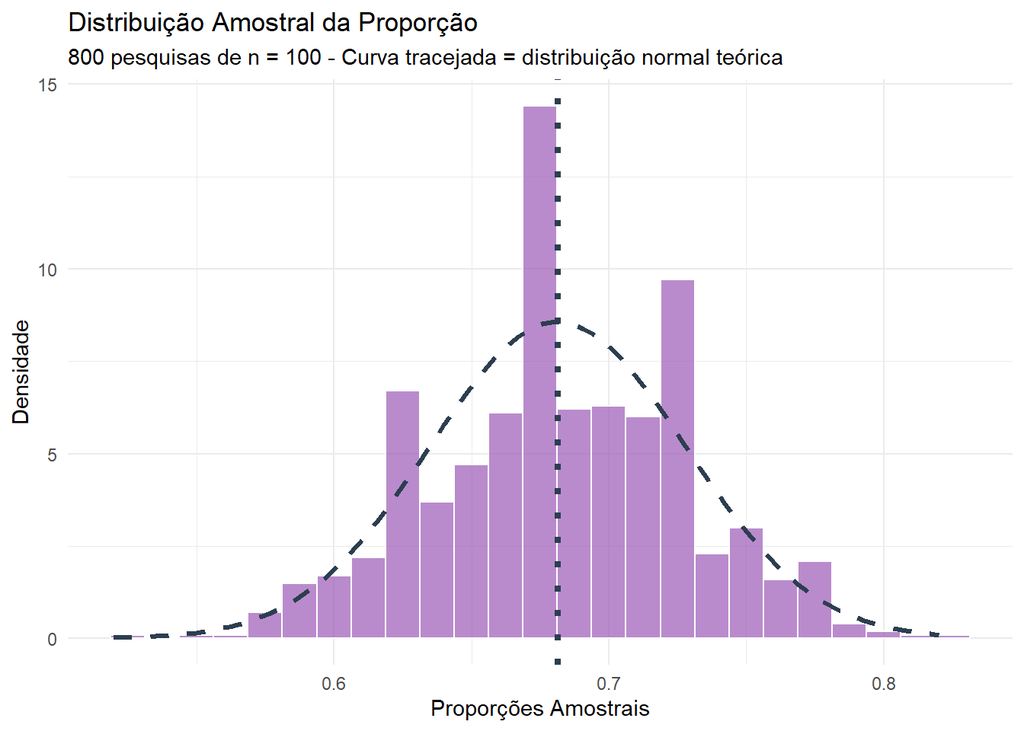

## 4.6 Teorema Central do Limite

Usaremos uma distribuição exponencial (altamente assimétrica) para demonstrar que médias amostrais tendem à normalidade independentemente da forma populacional.

**Cenário**: Tempo entre chegadas de clientes (distribuição exponencial - muitas chegadas rápidas, poucas esperas longas).

```
# A tibble: 3 × 2
  Característica             Valor
  <chr>                      <chr>
1 Média populacional         3.35
2 Desvio padrão populacional 3.38
3 Forma da distribuição      Exponencial (muito assimétrica)
```

```
# A tibble: 4 × 2
  tamanho                    n_observacoes
  <fct>                              <int>
1 "População\n(Exponencial)"          1000
2 "n = 2"                              500
3 "n = 10"                             500
4 "n = 40"                             500
```

## 4.7 TCL: Visualizando a Convergência para Normalidade

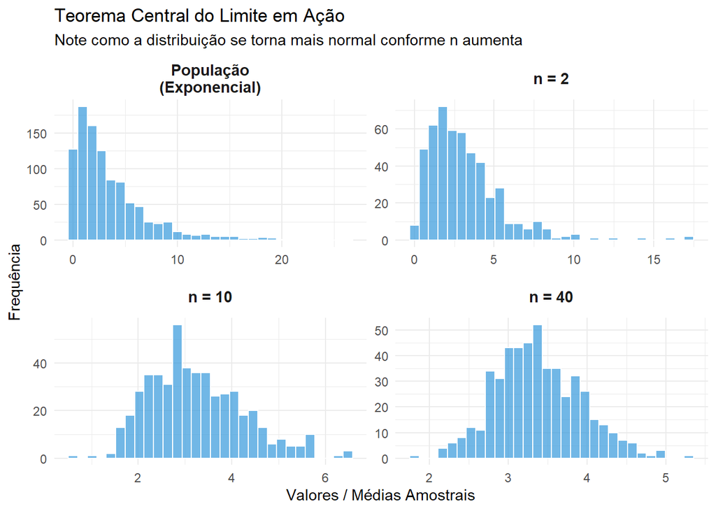

## 4.8 Quiz 4: Distribuições Amostrais

1. Para uma amostra de 36 observações com desvio-padrão s = 1.8, o erro-padrão de $\bar{x}$ é:
   1. 0.05
   2. 0.30
   3. 1.8
   4. 6.0
2. Para reduzir o erro-padrão de $\bar{x}$ pela metade, o tamanho da amostra deve ser:
   1. Dobrado
   2. Quadruplicado
   3. Reduzido pela metade
   4. Triplicado
3. O Teorema Central do Limite se refere à distribuição:
   1. Da população
   2. Da amostra
   3. Amostral do estimador
   4. Normal padrão